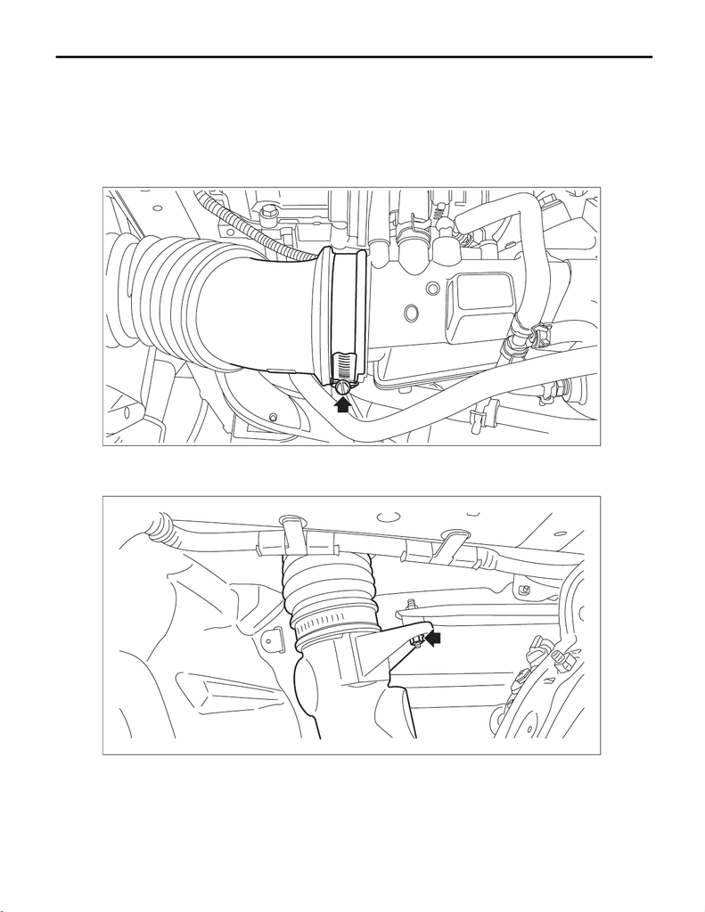

IN(w/o STI)-17

Air Intake Boot

INTAKE (INDUCTION)

4. Air Intake Boot

A: REMOVAL

1) Disconnect the ground terminal from battery sensor. <Ref. to NT-5, BATTERY, NOTE, Note.>

2) Remove the air cleaner case. <Ref. to IN(w/o STI)-9, REMOVAL, Air Cleaner Case.>

3) Lift up the vehicle.

4) Remove the under cover. <Ref. to EI-21, REMOVAL, Front Under Cover.>

5) Remove the air intake boot from the intake duct No. 1.

6) Lower the vehicle.

7) Remove the nuts which secure the turbo duct to the vehicle, and remove the air intake boot from the upper

side of the vehicle together with the turbo duct.

8) Lift up the vehicle.

IN-03534

IN-03554

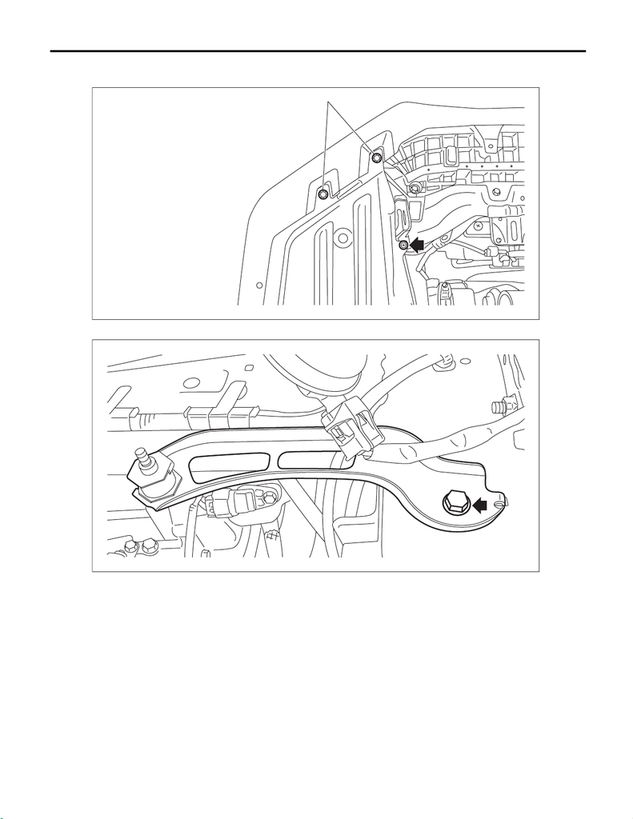

IN(w/o STI)-18

Air Intake Boot

INTAKE (INDUCTION)

9) Remove the clips (A) which secure the front mud guard RH to the front bumper, and remove the screw

which secures the front mud guard RH to the vehicle.

10) Turn over the front mud guard RH and remove the duct bracket from the vehicle.

(A)

IN-03555

IN-03556

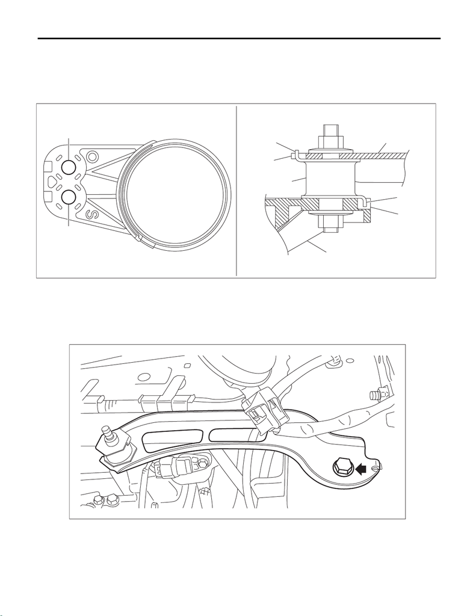

IN(w/o STI)-19

Air Intake Boot

INTAKE (INDUCTION)

B: INSTALLATION

Install in the reverse order of removal.

NOTE:

When installing the air intake boot to the vehicle, pay attention to the mounting hole position, and align the

protrusion for stopping rotation of cushion to the cutout portion on the turbo duct.

Tightening torque:

18 N·m (1.8 kgf-m, 13.3 ft-lb)

(a) Attachment hole (d) Cushion (g) Protrusion portion

(b) Not used (e) Duct bracket

(c) Turbo duct (f) Cutout portion

IN-03535

(b)

(a)

(g)

(f)

(c)

(d)

(f)

(g)

(e)

IN-03556

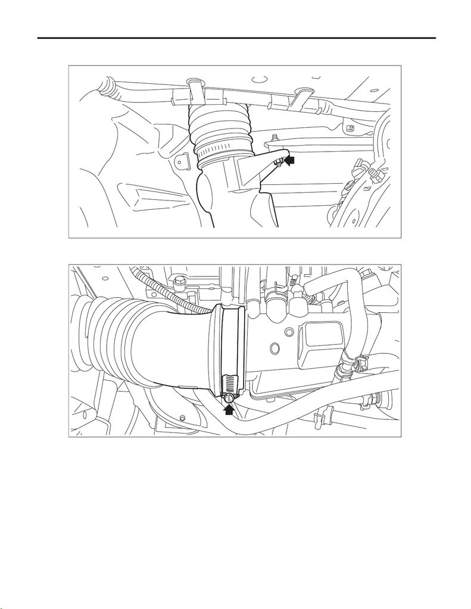

IN(w/o STI)-20

Air Intake Boot

INTAKE (INDUCTION)

Tightening torque:

7.5 N·m (0.8 kgf-m, 5.5 ft-lb)

Tightening torque:

2.5 N·m (0.3 kgf-m, 1.8 ft-lb)

IN-03554

IN-03534

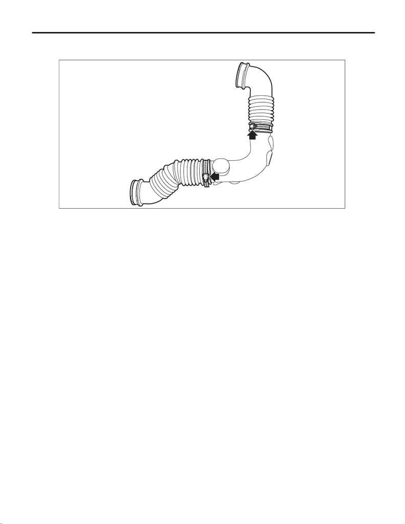

IN(w/o STI)-21

Air Intake Boot

INTAKE (INDUCTION)

C: DISASSEMBLY

Remove the air intake boot from the turbo duct.

D: ASSEMBLY

Assemble in the reverse order of disassembly.

Tightening torque:

2.5 N·m (0.3 kgf-m, 1.8 ft-lb)

E: INSPECTION

Check that the air intake boot and turbo duct have no cracks, damage or loose part.

IN-03225